# Uso de API de Covid19 con Pandas

Estamos usando esta url que es el proyecto y la otra url es la API

- https://covid19api.com/
- https://api.covid19api.com/

# Instalación Pandas

```python
!pip install pandas
```

## Configuración

Cada vez que llame a pandas lo voy a llamar pd y no pandas.

```python
import pandas as pd
```

# Variables

Es de las primeras cosas que se hacen. Vamos a crear la variable url que es donde está la información sobre los paises

```python
url ='https://api.covid19api.com/countries'
```

Esto lo hacemos para comprobar el valor de la url

```python
url
```

```
'https://api.covid19api.com/countries'
```

## Creación de *Dataframe*

Es una tabla a la que llamamos Dataframe, vamos a conectarnos a la tabla de la API y vamos a traer algunos. Como esta Api devuelve los datos en JSON, utilizamos la función `read_json` de *Pandas* para leer los datos en *JSON* de la *API*:

A nuestro dataframe lo vamos a llamar *df. Nuestra tabla de datos será la lectura y la url.

```python
df = pd.read_json(url)
```

Para comprobar que tenemos algo ahí, le decimos que muestre el dataframe y vemos una tabla de datos con 248 filas y 3 columnas. Lo que sale es un extracto y aparecen solo tres columnas porque pandas tiene una columna a la que la llama índice y no la considera como una columna de datos. Los datos que hemos extraido de la url tiene una columna que se llama *país,* slug y *el código internacional de cómo se llaman los paises.

```python
df
```

|  | Country | Slug | ISO2 |
| --- | --- | --- | --- |
| 0 | Faroe Islands | faroe-islands | FO |
| 1 | Portugal | portugal | PT |
| 2 | Mali | mali | ML |
| 3 | Azerbaijan | azerbaijan | AZ |
| 4 | British Virgin Islands | british-virgin-islands | VG |
| ... | ... | ... | ... |
| 243 | Syrian Arab Republic (Syria) | syria | SY |
| 244 | United Arab Emirates | united-arab-emirates | AE |
| 245 | Egypt | egypt | EG |
| 246 | Ethiopia | ethiopia | ET |
| 247 | Niger | niger | NE |

248 rows × 3 columns

## Explorar tabla

Vamos a utilizar unas funciones básicas del trabajo con datos:

- Cabecera
- Cola
- Info

```python
df.head()
```

|  | Country | Slug | ISO2 |
| --- | --- | --- | --- |
| 0 | Faroe Islands | faroe-islands | FO |
| 1 | Portugal | portugal | PT |
| 2 | Mali | mali | ML |
| 3 | Azerbaijan | azerbaijan | AZ |
| 4 | British Virgin Islands | british-virgin-islands | VG |

```python
df.tail()
```

|  | Country | Slug | ISO2 |
| --- | --- | --- | --- |
| 243 | Syrian Arab Republic (Syria) | syria | SY |
| 244 | United Arab Emirates | united-arab-emirates | AE |
| 245 | Egypt | egypt | EG |
| 246 | Ethiopia | ethiopia | ET |
| 247 | Niger | niger | NE |

Esta función habla de los datos que hay en vez de describe ya que proporciona información más interesante. Te dice que hay 248 países, que hay tres objetos y con eso sabes que las celdas no están vacías.

```python
df.info()
```

```
<class 'pandas.core.frame.DataFrame'>
RangeIndex: 248 entries, 0 to 247
Data columns (total 3 columns):
 #   Column   Non-Null Count  Dtype
---  ------   --------------  -----
 0   Country  248 non-null    object
 1   Slug     248 non-null    object
 2   ISO2     248 non-null    object
dtypes: object(3)
memory usage: 5.9+ KB
```

## Acceso de datos

Esto lo hacemos para ver la lista de la columna *Country. Te hace un extracto de los primeros y los últimos.

```python
df['Country']
```

```
0                     Faroe Islands
1                          Portugal
2                              Mali
3                        Azerbaijan
4            British Virgin Islands
                   ...
243    Syrian Arab Republic (Syria)
244            United Arab Emirates
245                           Egypt
246                        Ethiopia
247                           Niger
Name: Country, Length: 248, dtype: object
```

Si sabes el valor del índice puedes indicarlo entre corchetes y te aparece.

```python
df['Country'][200]
```

```
'Bolivia'
```

## Tiempo real

```python
url_live = 'https://api.covid19api.com/country/spain/status/confirmed/live'
df_es = pd.read_json(url_live)
df_es
```

|  | Country | CountryCode | Province | City | CityCode | Lat | Lon | Cases | Status | Date |
| --- | --- | --- | --- | --- | --- | --- | --- | --- | --- | --- |
| 0 | Spain | ES |  |  |  | 40.46 | -3.75 | 0 | confirmed | 2020-01-22 00:00:00+00:00 |
| 1 | Spain | ES |  |  |  | 40.46 | -3.75 | 0 | confirmed | 2020-01-23 00:00:00+00:00 |
| 2 | Spain | ES |  |  |  | 40.46 | -3.75 | 0 | confirmed | 2020-01-24 00:00:00+00:00 |
| 3 | Spain | ES |  |  |  | 40.46 | -3.75 | 0 | confirmed | 2020-01-25 00:00:00+00:00 |
| 4 | Spain | ES |  |  |  | 40.46 | -3.75 | 0 | confirmed | 2020-01-26 00:00:00+00:00 |
| ... | ... | ... | ... | ... | ... | ... | ... | ... | ... | ... |
| 799 | Spain | ES |  |  |  | 40.46 | -3.75 | 11508309 | confirmed | 2022-03-31 00:00:00+00:00 |
| 800 | Spain | ES |  |  |  | 40.46 | -3.75 | 11551574 | confirmed | 2022-04-01 00:00:00+00:00 |
| 801 | Spain | ES |  |  |  | 40.46 | -3.75 | 11551574 | confirmed | 2022-04-02 00:00:00+00:00 |
| 802 | Spain | ES |  |  |  | 40.46 | -3.75 | 11551574 | confirmed | 2022-04-03 00:00:00+00:00 |
| 803 | Spain | ES |  |  |  | 40.46 | -3.75 | 11551574 | confirmed | 2022-04-04 00:00:00+00:00 |

804 rows × 10 columns

Aquí hacemos lo mismo para extraer información. El termino float hace alusión a los decimales, int a los números enteros, object es texto, datetime es espacio del tiempo.

```python
df_es.info()
```

```
<class 'pandas.core.frame.DataFrame'>
RangeIndex: 804 entries, 0 to 803
Data columns (total 10 columns):
 #   Column       Non-Null Count  Dtype
---  ------       --------------  -----
 0   Country      804 non-null    object
 1   CountryCode  804 non-null    object
 2   Province     804 non-null    object
 3   City         804 non-null    object
 4   CityCode     804 non-null    object
 5   Lat          804 non-null    float64
 6   Lon          804 non-null    float64
 7   Cases        804 non-null    int64
 8   Status       804 non-null    object
 9   Date         804 non-null    datetime64[ns, UTC]
dtypes: datetime64[ns, UTC](1), float64(2), int64(1), object(6)
memory usage: 62.9+ KB
```

Para aprovecharnos de la columna de control de Pandas, convertimos la columna de datos de *fecha en la columna de* índice. Me va a venir bien para trabajar con el gráfico de líneas.

En el dataframe de España aplico la función set_index y le digo que el índice sea la columna fecha.

```python
df_es.set_index('Date')
```

| Date | Country | CountryCode | Province | City | CityCode | Lat | Lon | Cases | Status |
| --- | --- | --- | --- | --- | --- | --- | --- | --- | --- |
| 2020-01-22 00:00:00+00:00 | Spain | ES |  |  |  | 40.46 | -3.75 | 0 | confirmed |
| 2020-01-23 00:00:00+00:00 | Spain | ES |  |  |  | 40.46 | -3.75 | 0 | confirmed |
| 2020-01-24 00:00:00+00:00 | Spain | ES |  |  |  | 40.46 | -3.75 | 0 | confirmed |
| 2020-01-25 00:00:00+00:00 | Spain | ES |  |  |  | 40.46 | -3.75 | 0 | confirmed |
| 2020-01-26 00:00:00+00:00 | Spain | ES |  |  |  | 40.46 | -3.75 | 0 | confirmed |
| ... | ... | ... | ... | ... | ... | ... | ... | ... | ... |
| 2022-03-31 00:00:00+00:00 | Spain | ES |  |  |  | 40.46 | -3.75 | 11508309 | confirmed |
| 2022-04-01 00:00:00+00:00 | Spain | ES |  |  |  | 40.46 | -3.75 | 11551574 | confirmed |
| 2022-04-02 00:00:00+00:00 | Spain | ES |  |  |  | 40.46 | -3.75 | 11551574 | confirmed |
| 2022-04-03 00:00:00+00:00 | Spain | ES |  |  |  | 40.46 | -3.75 | 11551574 | confirmed |
| 2022-04-04 00:00:00+00:00 | Spain | ES |  |  |  | 40.46 | -3.75 | 11551574 | confirmed |

804 rows × 9 columns

Los otros datos que me gustaría incluir en esta tabla que acabo de construir. Hago una llamada a la columna *casos

```python
df_es.set_index('Date')['Cases']
```

```
Date
2020-01-22 00:00:00+00:00           0
2020-01-23 00:00:00+00:00           0
2020-01-24 00:00:00+00:00           0
2020-01-25 00:00:00+00:00           0
2020-01-26 00:00:00+00:00           0
                               ...
2022-03-31 00:00:00+00:00    11508309
2022-04-01 00:00:00+00:00    11551574
2022-04-02 00:00:00+00:00    11551574
2022-04-03 00:00:00+00:00    11551574
2022-04-04 00:00:00+00:00    11551574
Name: Cases, Length: 804, dtype: int64
```

## Tiempo real en España

Ahora le digo que a toda ese objeto le haga un *plot(), es decir, un gráfico con los datos en tiempo real de España.

Dentro del parantesis le vamos a dar el tributo titulo.

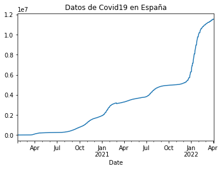

```python
df_es.set_index('Date')['Cases'].plot(title="Datos de Covid19 en España")
```

## Tiempo real en Colombia

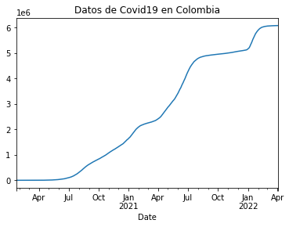

```python
url_co = 'https://api.covid19api.com/country/colombia/status/confirmed/live'
df_co = pd.read_json(url_co)
df_co.set_index ('Date') ['Cases'].plot(title="Datos de Covid19 en Colombia")
```

## Comparativa España - Colombia

Aquí estamos haciendo estas tablas con los casos de España y los de Colombia basándonos en las tablas de origen

```python
casos_es= df_es.set_index('Date')['Cases']
casos_co= df_co.set_index('Date')['Cases']
```

```python
casos_co
```

```
Date
2020-01-22 00:00:00+00:00          0
2020-01-23 00:00:00+00:00          0
2020-01-24 00:00:00+00:00          0
2020-01-25 00:00:00+00:00          0
2020-01-26 00:00:00+00:00          0
                              ...
2022-03-31 00:00:00+00:00    6084916
2022-04-01 00:00:00+00:00    6085270
2022-04-02 00:00:00+00:00    6085618
2022-04-03 00:00:00+00:00    6085926
2022-04-04 00:00:00+00:00    6086233
Name: Cases, Length: 804, dtype: int64
```

Empleamos una nueva función de pandas que se llama concatenar y a esta le decimos que aparezcan los casos de españa y los casos de colombia y lo haga en el eje 1, es decir, lo pone a la derecha.

```python
pd.concat([casos_es, casos_co], axis=1)
```

| Date | Cases | Cases |
| --- | --- | --- |
| 2020-01-22 00:00:00+00:00 | 0 | 0 |
| 2020-01-23 00:00:00+00:00 | 0 | 0 |
| 2020-01-24 00:00:00+00:00 | 0 | 0 |
| 2020-01-25 00:00:00+00:00 | 0 | 0 |
| 2020-01-26 00:00:00+00:00 | 0 | 0 |
| ... | ... | ... |
| 2022-03-31 00:00:00+00:00 | 11508309 | 6084916 |
| 2022-04-01 00:00:00+00:00 | 11551574 | 6085270 |
| 2022-04-02 00:00:00+00:00 | 11551574 | 6085618 |
| 2022-04-03 00:00:00+00:00 | 11551574 | 6085926 |
| 2022-04-04 00:00:00+00:00 | 11551574 | 6086233 |

804 rows × 2 columns

Ahora vamos a meter esto en un nuevo objeto al que le llamamos vs para guardar la concatenación.

```python
vs = pd.concat([casos_es, casos_co], axis=1)
vs
```

| Date | Cases | Cases |
| --- | --- | --- |
| 2020-01-22 00:00:00+00:00 | 0 | 0 |
| 2020-01-23 00:00:00+00:00 | 0 | 0 |
| 2020-01-24 00:00:00+00:00 | 0 | 0 |
| 2020-01-25 00:00:00+00:00 | 0 | 0 |
| 2020-01-26 00:00:00+00:00 | 0 | 0 |
| ... | ... | ... |
| 2022-03-31 00:00:00+00:00 | 11508309 | 6084916 |
| 2022-04-01 00:00:00+00:00 | 11551574 | 6085270 |
| 2022-04-02 00:00:00+00:00 | 11551574 | 6085618 |
| 2022-04-03 00:00:00+00:00 | 11551574 | 6085926 |
| 2022-04-04 00:00:00+00:00 | 11551574 | 6086233 |

804 rows × 2 columns

Como los nombres las columnas son muy feos les vamos a indicar un nombre.

```python
vs.columns = ['España', 'Colombia']
vs
```

| Date | España | Colombia |
| --- | --- | --- |
| 2020-01-22 00:00:00+00:00 | 0 | 0 |
| 2020-01-23 00:00:00+00:00 | 0 | 0 |
| 2020-01-24 00:00:00+00:00 | 0 | 0 |
| 2020-01-25 00:00:00+00:00 | 0 | 0 |
| 2020-01-26 00:00:00+00:00 | 0 | 0 |
| ... | ... | ... |
| 2022-03-31 00:00:00+00:00 | 11508309 | 6084916 |
| 2022-04-01 00:00:00+00:00 | 11551574 | 6085270 |
| 2022-04-02 00:00:00+00:00 | 11551574 | 6085618 |
| 2022-04-03 00:00:00+00:00 | 11551574 | 6085926 |
| 2022-04-04 00:00:00+00:00 | 11551574 | 6086233 |

804 rows × 2 columns

Esto lo hacemos para que aparezca el grafico con la comparativa podemos indicar que tipo de gráfico puede ser con el atributo *kind

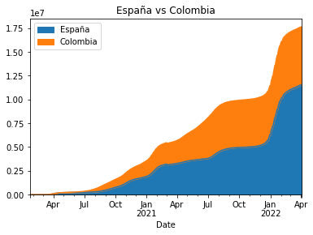

```python
vs.plot(title="España vs Colombia", kind='area')
```

## Tiempo real en México

```python
Indicamos que el objeto se llame vs3 porque es diferente a los otros
```

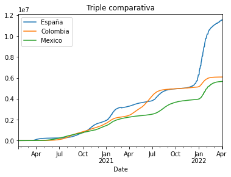

```python
url_mex = 'https://api.covid19api.com/country/mexico/status/confirmed/live'
df_mex = pd.read_json(url_mex)
df_mex.set_index('Date')
df_mex.set_index('Date')['Cases']
casos_mex = df_mex.set_index ('Date')['Cases']
vs3 = pd.concat([casos_es,casos_co,casos_mex], axis=1)
vs3.columns = ['España','Colombia','Mexico']
vs3.plot(title="Triple comparativa")
```

## Seleccionar más columnas

```python
df_es.set_index('Date')[['Cases', 'Lon']]
```

| Date | Cases | Lon |
| --- | --- | --- |
| 2020-01-22 00:00:00+00:00 | 0 | -3.75 |
| 2020-01-23 00:00:00+00:00 | 0 | -3.75 |
| 2020-01-24 00:00:00+00:00 | 0 | -3.75 |
| 2020-01-25 00:00:00+00:00 | 0 | -3.75 |
| 2020-01-26 00:00:00+00:00 | 0 | -3.75 |
| ... | ... | ... |
| 2022-03-31 00:00:00+00:00 | 11508309 | -3.75 |
| 2022-04-01 00:00:00+00:00 | 11551574 | -3.75 |
| 2022-04-02 00:00:00+00:00 | 11551574 | -3.75 |
| 2022-04-03 00:00:00+00:00 | 11551574 | -3.75 |
| 2022-04-04 00:00:00+00:00 | 11551574 | -3.75 |

804 rows × 2 columns

## Exportar datos

Queremos convertir el objeto vs en csv

```python
vs.to_csv('vs.csv')
```

Voy a crear un objeto grafico y después empleo el método figura y me lo guardo

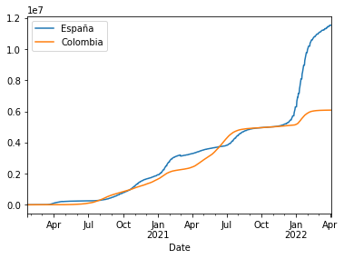

```python
grafico = vs.plot()
fig = grafico.get_figure()
fig.savefig("vs.png")
```